# Activity Classification from Wearable Device Measurements

Peter Thompson

26 May 2017

# Introduction

Data comes from the [Groupware Human Activity Recognition](http://groupware.les.inf.puc-rio.br/har) dataset. The aim of this project is to use machine learning to predict whether a subject is performing a weight lifting excercise correctly, or making one of several common mistakes.

Data is first loaded and tidied, then a short exploratory analysis is carried out before several models are trained and assessed.

# Data Partitioning

First load required R libraries and set chunk options (messages/warnings for this chunk are suppressed).

```r
library(knitr)
opts_chunk$set(fig.width=6, fig.height=6,dpi=108)
library(ggplot2)
library(dplyr)
library(caret)
library(ranger)
library(MASS)
library(reshape2)
library(GGally)
```

Load data.

```r
training<-read.csv('./data/pml-training.csv',stringsAsFactors=TRUE,na.strings = c("#DIV/0!","NA"))
dim(training)
```

```
## [1] 19622   160
```

```r
# convert cvtd_timestamp to posixlt class
training$cvtd_timestamp<-strptime(training$cvtd_timestamp,format = "%d/%m/%Y %H:%M")
```

The activity classification is specified in the `classe` variable. In the training dataset, this is highly correlated with time information. This can be seen by plotting `classe` vs `raw_timestamp_part_1`

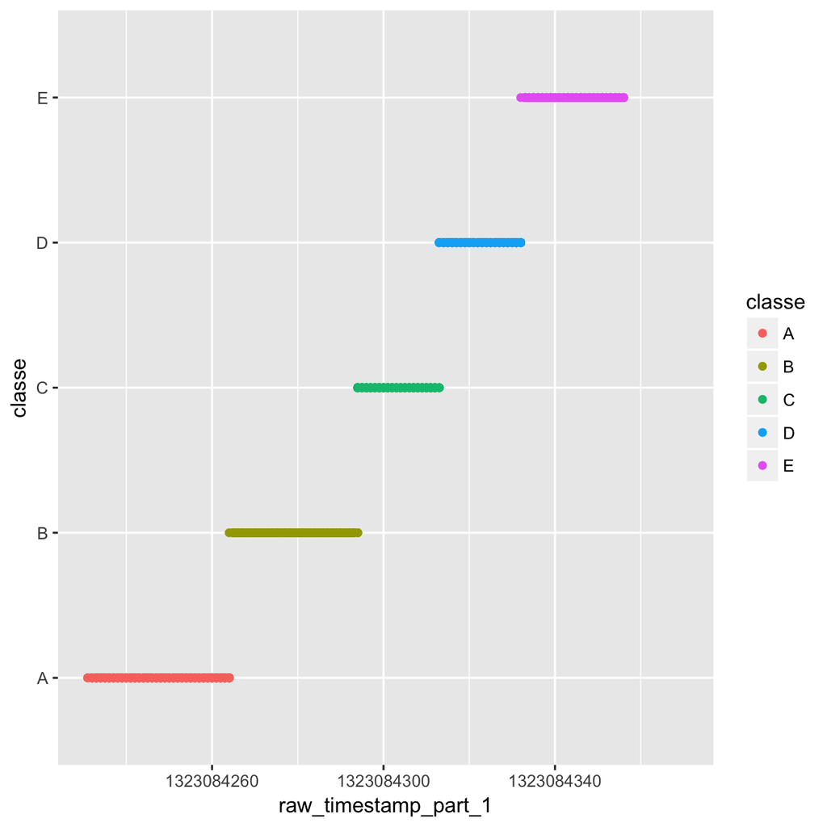

```r
h<- ggplot(data=training,aes(x=raw_timestamp_part_1,y=classe,colour=classe)) + geom_point()
print(h + scale_x_continuous(limits=c(1323084231,1323084370)))
```

In this scenario, a model that incorporates time information as a predictor will not be useful when applied to new data. A good model should be able to predict based on just the sensor data. Will omit subject name, time, and window information from the training dataset, As these would not be useful predictors for measurements taken at later dates.

Also, there are a lot of missing values for a number of variables. These could be imputed, but for some of these columns only about 1.5% of the measurements are present. These variables will be omitted.

Finally, the “training” data will be repartitioned into training and validation sets. The validation set will be used to assess each model.

```r
na_list<-sapply(training,function(x) { sum(is.na(x))})
good<- na_list < 1900
nona<-training[good]
# remove name, time, window info
slimmed<-nona[,-(1:7)]
#str(slimmed)

# create training and validation partitions from original "training" set
inTrain<-createDataPartition(slimmed$classe,p=0.8,list=FALSE)
slimtr<-slimmed[inTrain,]
slimval<-slimmed[-inTrain,]
```

# Exploratory Analysis

A plot of the correlation between predictor variables is shown below.

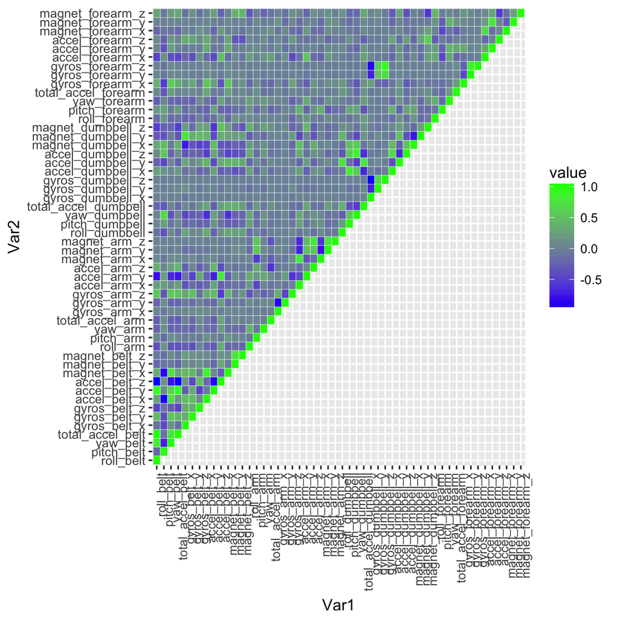

```r
thecorr<-cor(slimmed[-53])
thecorr[lower.tri(thecorr)]<- NA
mcm<-melt(thecorr,na.rm=TRUE)
#head(mcm)
corrplot<-ggplot(data=mcm,aes(x=Var1,y=Var2,fill=value)) + geom_tile(colour='white') +
 scale_fill_gradientn(colours=c('blue','green')) +theme(axis.text.x = element_text(angle = 90, hjust = 1))
print(corrplot)
```

There are a few patterns between off diagonal elements, indicating correlation between predictors. For example, the total acceleration of the dumbbell and the x and y components of the dumbbell gyro measurements are strongly (anti) correlated with the y and z components of the forearm gyro measurements. This suggests that a Principal Components Analysis (PCA) may be able to reduce the number of variables that need be considered while retaining the observed variance.

A pairs plot of the first 7 variables is shown below.

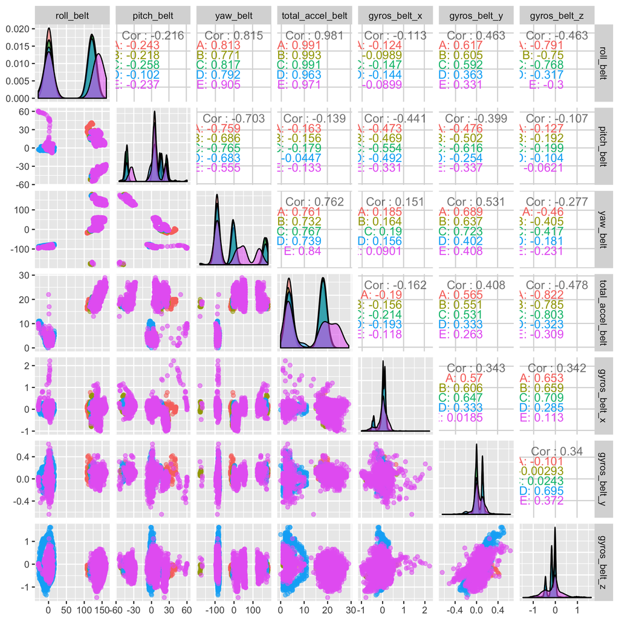

```r
h<-ggpairs(data=slimtr,columns=1:7,mapping=ggplot2::aes(colour = classe,alpha=0.02))
print(h)
```

# Model Selection

## Linear Discriminant analysis.

Linear discriminant analysis is a classification technique, and is described in detail in [Elements of Statistical Learining](https://statweb.stanford.edu/~tibs/ElemStatLearn/). Each of the $k$ classes is assumed to have a probability density in the form of a multivariate Gaussian:

$f_k(x) = \frac{1} {(2\pi)^{p/2} | \Sigma|^{1/2}}e^{-\frac{1}{2} (x - \mu_k)^T\Sigma^{-1} (x - \mu_k) }$ where $x$ is a column vector of predictor variables, $\mu_k$ is the mean of $x$ for class $k$, and $\Sigma$ is the covariance matrix for the predictor variables (and is assumed to be the same for all classes). The discriminant function for class $k$ is then given by $\delta_k(x) = x^T\Sigma^{-1} \mu_k - \frac{1}{2} \mu_k^T \Sigma^{-1}\mu_k + \log \pi_k$

where $\pi_k$ is the prior probability of class $k$ and can be estimated as $N_k/N$, where $N$ is the total number of training observations and $N_k$ is the number of observations in class $k$. The ratio $\delta_i(x) / \delta_j(x)$ is then equivalent to the log ratio of the conditional probabilities for the observation to lie in class $i$/$j$. Thus, a given observation $x$ is most likely to belong to the class with the highest discriminant function. As the discriminant functions are linear, the phase space covered by the predictor variables is broken up into multiple regions seperated by hyper-planes, where each region is associated with a single class.

```r
set.seed(5074491)
starttime<-Sys.time()
tr_c<-trainControl(method='repeatedcv',number=10,repeats =3,allowParallel=TRUE)
ldafit<-train(classe ~ . , data=slimtr, method='lda',trainControl=tr_c, preProcess=c('center','scale'))
endtime<-Sys.time()
endtime - starttime
```

```
## Time difference of 17.66754 secs
```

### Model Assessment

The performance of the lda model is summarised below.

```r
ldafit$results
```

```
##   parameter  Accuracy    Kappa  AccuracySD     KappaSD
## 1      none 0.6982852 0.618285 0.005548499 0.007233247
```

```r
# ldafit$finalModel

# confusionMatrix
ldapred<-predict(ldafit,newdata=slimval)
confusionMatrix(data=ldapred,reference=slimval$classe)
```

```
## Confusion Matrix and Statistics
##
##           Reference
## Prediction   A   B   C   D   E
##          A 933 110  70  48  36
##          B  29 494  61  24 127
##          C  77  81 449  72  61
##          D  76  31  88 479  66
##          E   1  43  16  20 431
##
## Overall Statistics
##
##                Accuracy : 0.7102
##                  95% CI : (0.6957, 0.7243)
##     No Information Rate : 0.2845
##     P-Value [Acc > NIR] : < 2.2e-16
##
##                   Kappa : 0.6328
##  Mcnemar's Test P-Value : < 2.2e-16
##
## Statistics by Class:
##
##                      Class: A Class: B Class: C Class: D Class: E
## Sensitivity            0.8360   0.6509   0.6564   0.7449   0.5978
## Specificity            0.9059   0.9238   0.9102   0.9204   0.9750
## Pos Pred Value         0.7794   0.6721   0.6068   0.6473   0.8434
## Neg Pred Value         0.9329   0.9169   0.9262   0.9485   0.9150
## Prevalence             0.2845   0.1935   0.1744   0.1639   0.1838
## Detection Rate         0.2378   0.1259   0.1145   0.1221   0.1099
## Detection Prevalence   0.3051   0.1874   0.1886   0.1886   0.1303
## Balanced Accuracy      0.8710   0.7873   0.7833   0.8327   0.7864
```

Based on cross validation, this model has an estimated out-of-sample accuracy of $\sim70%$ and a $\kappa$ (kappa) value of 0.618. Kappa describes how well the model accuraccy compares to just random guessing; a value of 1.0 indicates perfect agreement, while 0.0 indicates pure chance (i.e. the ‘model’ is essentially a coin flip or die roll). Similar accuracy (0.71) and $\kappa$ (0.63) values are found when predicting on the validation set. The confusion matrix summarises the (mis)classification of the validation set.

An accuracy of $\sim70\%$ is not bad, but other models may perform better.

## Random Forest

Will use the random forest implementation from the ranger package. Random forests generate an ensemble of decision trees. Each tree is trained on a bootstrap resample of the data, and only a random subset of the predictor variables are considered at each split in the tree.

For cross validtion, will use k-fold cross validation with 10 folds repeated 3 times. Random forests don’t neccesarily need to be cross-validated, this will be discuessed below.

```r
set.seed(5074491)
starttime<-Sys.time()
tr_c<-trainControl(method='repeatedcv',number=10,repeats =3,allowParallel=TRUE)

model_rangerInitial<-train(classe ~ .  ,data=slimtr,method='ranger',trControl=tr_c,tuneGrid = expand.grid(mtry=c(5,10,15)),importance='impurity')
endtime<-Sys.time()
endtime - starttime
```

```
## Time difference of 6.619064 mins
```

```r
model_rangerInitial
```

```
## Random Forest
##
## 15699 samples
##    52 predictor
##     5 classes: 'A', 'B', 'C', 'D', 'E'
##
## No pre-processing
## Resampling: Cross-Validated (10 fold, repeated 3 times)
## Summary of sample sizes: 14129, 14129, 14130, 14128, 14129, 14130, ...
## Resampling results across tuning parameters:
##
##   mtry  Accuracy   Kappa
##    5    0.9946707  0.9932587
##   10    0.9951590  0.9938764
##   15    0.9945644  0.9931243
##
## Accuracy was used to select the optimal model using  the largest value.
## The final value used for the model was mtry = 10.
```

This performs pretty well. Model accuracy and $\kappa$ are both greater than 99%. The optimal value of `mtry` was found to be 10, so will look for an optimal value close to that.

```r
set.seed(5074491)
starttime<-Sys.time()
# tr_c<-trainControl(method='repeatedcv',number=20,repeats=5,allowParallel=TRUE)
tr_c<-trainControl(method='repeatedcv',number=10,repeats =3,allowParallel=TRUE)

# 20 fold cross validation, repeated 5 times
# can also select 'oob' for out of bag
# model_ranger_nopca<-train(classe~.,data=slim2,method='ranger',trControl=tr_c)
model_rangerTuned<-train(classe ~ .  ,data=slimtr,method='ranger',trControl=tr_c,tuneGrid = expand.grid(mtry= c(6,8,9,10,11,12)),importance='impurity')
endtime<-Sys.time()
endtime - starttime
```

```
## Time difference of 13.06467 mins
```

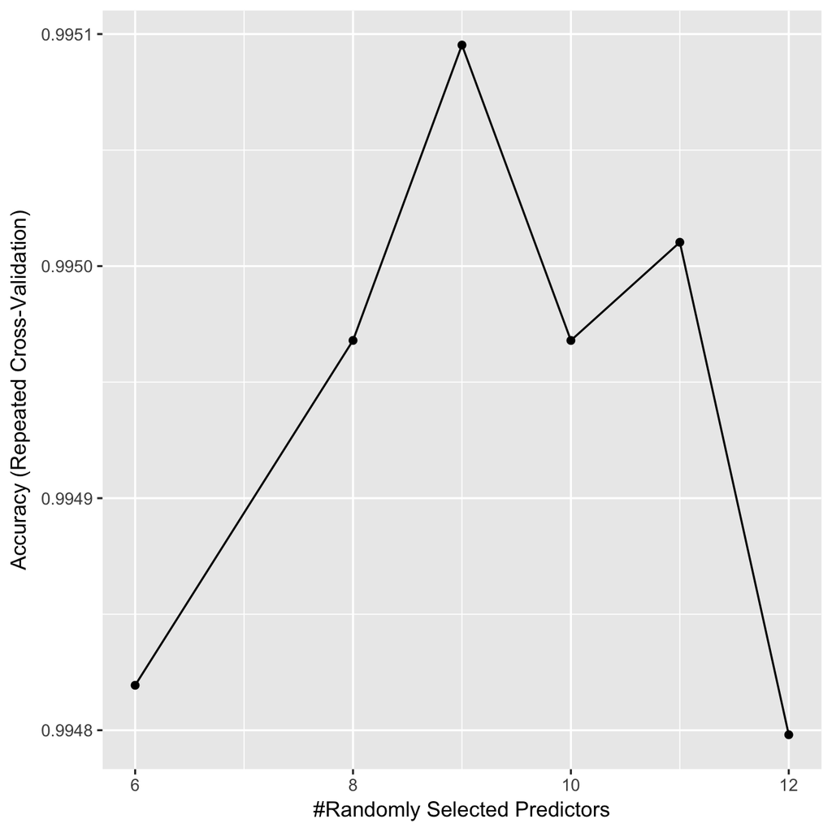

```r
ggplot(model_rangerTuned)
```

The optimal value of mtry is found to be 9.

### Model Assessment

```r
model_rangerTuned$finalModel
```

```
## Ranger result
##
## Call:
##  ranger(.outcome ~ ., data = x, mtry = param$mtry, write.forest = TRUE,      probability = classProbs, ...)
##
## Type:                             Classification
## Number of trees:                  500
## Sample size:                      15699
## Number of independent variables:  52
## Mtry:                             9
## Target node size:                 1
## Variable importance mode:         impurity
## OOB prediction error:             0.40 %
```

Random forests can estimate out of sample accuracy using “out-of-bag” samples. Each tree in the forest is trained using a bootstrapped resample of the training set, and so there are some observations in the training data that a given tree was not exposed to. These observations can be used to assess the tree’s accuracy. The accuracy of the forest can be estimated by having it predict on the training set, but only using predictions from trees which were not trained on the observation being predicted. This is the out-of-bag error rate. The optimal model above has an out-of-bagbag error of 0.4%, or an accuracy of 99.6%.

```r
model_rangerTuned
```

```
## Random Forest
##
## 15699 samples
##    52 predictor
##     5 classes: 'A', 'B', 'C', 'D', 'E'
##
## No pre-processing
## Resampling: Cross-Validated (10 fold, repeated 3 times)
## Summary of sample sizes: 14129, 14129, 14130, 14128, 14129, 14130, ...
## Resampling results across tuning parameters:
##
##   mtry  Accuracy   Kappa
##    6    0.9948194  0.9934466
##    8    0.9949680  0.9936347
##    9    0.9950953  0.9937958
##   10    0.9949680  0.9936348
##   11    0.9950103  0.9936883
##   12    0.9947981  0.9934198
##
## Accuracy was used to select the optimal model using  the largest value.
## The final value used for the model was mtry = 9.
```

From the repeated k-fold cross-validation, model accuracy (at mtry=9) is estimated at 99.5% and $\kappa$ at 99.38%. These values are extremely good, which is nice. The accuracy is also consisted with the out-of-bag error rate.

An independant assessment of model accuracy can be obtained by predicting on the validation set

```r
# This is the confusion matrix generated by applying the final model to the vaidation set
rangerTunedpred<-predict(model_rangerTuned,newdata=slimval)
confusionMatrix(data=rangerTunedpred,reference=slimval$classe)
```

```
## Confusion Matrix and Statistics
##
##           Reference
## Prediction    A    B    C    D    E
##          A 1116    3    0    0    0
##          B    0  756    1    0    0
##          C    0    0  682    2    0
##          D    0    0    1  640    0
##          E    0    0    0    1  721
##
## Overall Statistics
##
##                Accuracy : 0.998
##                  95% CI : (0.996, 0.9991)
##     No Information Rate : 0.2845
##     P-Value [Acc > NIR] : < 2.2e-16
##
##                   Kappa : 0.9974
##  Mcnemar's Test P-Value : NA
##
## Statistics by Class:
##
##                      Class: A Class: B Class: C Class: D Class: E
## Sensitivity            1.0000   0.9960   0.9971   0.9953   1.0000
## Specificity            0.9989   0.9997   0.9994   0.9997   0.9997
## Pos Pred Value         0.9973   0.9987   0.9971   0.9984   0.9986
## Neg Pred Value         1.0000   0.9991   0.9994   0.9991   1.0000
## Prevalence             0.2845   0.1935   0.1744   0.1639   0.1838
## Detection Rate         0.2845   0.1927   0.1738   0.1631   0.1838
## Detection Prevalence   0.2852   0.1930   0.1744   0.1634   0.1840
## Balanced Accuracy      0.9995   0.9979   0.9982   0.9975   0.9998
```

The tuned model performs extremely well on the validation set, with very few misclassifications. Accuracy and $\kappa$ are 0.998 and 0.997, respectively. These are slightly higher than the cross validation or out-of-bag estimates, which is interesting. Based on these values, I would expect this model to have an **out-of-sample error rate** of 0.002.

Note that the confusion matrix obtained from out-of bag predictions performs similarly well

```r
# Confusion matrix
# this one is generated from the training set using out-of-bag samples
model_rangerTuned$finalModel$confusion.matrix
```

```
##     predicted
## true    A    B    C    D    E
##    A 4464    0    0    0    0
##    B   10 3023    5    0    0
##    C    0   14 2720    4    0
##    D    0    0   24 2547    2
##    E    0    0    2    2 2882
```

The relative importance of the predictor variables is shown below.

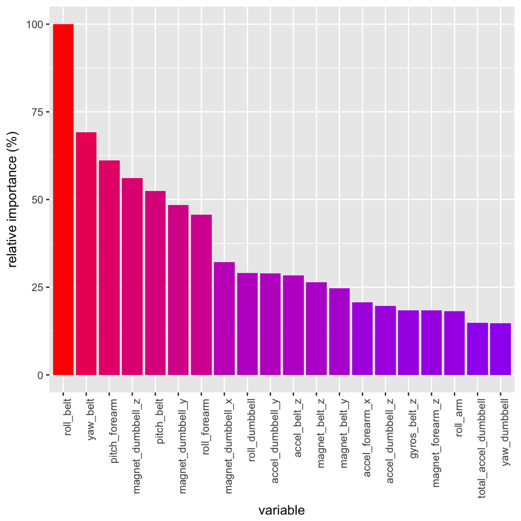

```r
# plot variable importance
varimps<-varImp(model_rangerTuned)
imps<-data.frame(var=row.names(varimps$importance),importance=varimps$importance)
importance<-data.frame(var=row.names(imps$importance),Overall=imps$importance)
# keep only top 20 variables
imps<-imps[order(imps$Overall,decreasing=TRUE)[1:20],]
h<-ggplot(data=imps,aes(x=var,weight=Overall,fill=Overall)) + geom_bar() +
scale_x_discrete(limits=imps$var) + scale_fill_gradientn(colors=c('purple','red')) + labs(y="relative importance (%)",x="variable") +
theme(axis.text.x = element_text(angle = 90, hjust = 1)) + guides(fill=FALSE)
print(h)
```

The roll measurement from the belt sensor is the most significant in this model. The other belt rotation measures (pitch and yaw) are also quite important, as well as pitch and roll of the forearm.

## Dimension Reduction/Compression

Random forests can run into difficulties when there are a few important predictors hidden amongst a large number of variables. (because we only sample a subset of the predictors at each branch, so there is a small probability of getting a good variable). Principal Components Analysis can be used to reduce the number of predictor variables, which may improve things.

### Number of Components

First, get an idea of how many components are needed to capture a certain amount of variance

```r
set.seed(5074491)
preproc<-preProcess(slimtr[-53],method='pca',thresh=0.95)
preproc$numComp
```

```
## [1] 25
```

```r
preproc<-preProcess(slimtr[-53],method='pca',thresh=0.90)
preproc$numComp
```

```
## [1] 18
```

```r
preproc<-preProcess(slimtr[-53],method='pca',thresh=0.85)
preproc$numComp
```

```
## [1] 15
```

### Model Training

```r
set.seed(5074491)
starttime<-Sys.time()
# tr_c<-trainControl(method='repeatedcv',number=20,repeats=5,allowParallel=TRUE)
tr_c<-trainControl(method='repeatedcv',number=10,repeats=3,allowParallel=TRUE,preProcOptions = list(pcaComp = 26))
model_rangerPCA<-train(classe ~ .  ,data=slimtr,method='ranger',trControl=tr_c,tuneGrid = expand.grid( mtry= c(2,3,4,5)),importance='impurity',preProcess='pca')
endtime<-Sys.time()
endtime - starttime
```

```
## Time difference of 14.30615 mins
```

Took a (relatively) long time for only 4 mtry values and a reduced number of predictors.

### Model Assessment

```r
model_rangerPCA
```

```
## Random Forest
##
## 15699 samples
##    52 predictor
##     5 classes: 'A', 'B', 'C', 'D', 'E'
##
## Pre-processing: principal component signal extraction (52), centered
##  (52), scaled (52)
## Resampling: Cross-Validated (10 fold, repeated 3 times)
## Summary of sample sizes: 14129, 14129, 14130, 14128, 14129, 14130, ...
## Resampling results across tuning parameters:
##
##   mtry  Accuracy   Kappa
##   2     0.9764108  0.9701556
##   3     0.9764954  0.9702632
##   4     0.9762834  0.9699960
##   5     0.9759224  0.9695393
##
## Accuracy was used to select the optimal model using  the largest value.
## The final value used for the model was mtry = 3.
```

```r
# model_rangerPCA$finalModel
# confusionMatrix
# model_rangerPCA$finalModel$confusion.matrix
rangerPCApred<-predict(model_rangerPCA,newdata=slimval,predict.all=TRUE)
# dim(rangerPCApred)
# confusion matrix from vlidation set
confusionMatrix(data=rangerPCApred,reference=slimval$classe)
```

```
## Confusion Matrix and Statistics
##
##           Reference
## Prediction    A    B    C    D    E
##          A 1112   11    2    1    0
##          B    1  743    5    0    1
##          C    2    2  673   18    4
##          D    1    0    4  624    0
##          E    0    3    0    0  716
##
## Overall Statistics
##
##                Accuracy : 0.986
##                  95% CI : (0.9818, 0.9894)
##     No Information Rate : 0.2845
##     P-Value [Acc > NIR] : < 2.2e-16
##
##                   Kappa : 0.9823
##  Mcnemar's Test P-Value : NA
##
## Statistics by Class:
##
##                      Class: A Class: B Class: C Class: D Class: E
## Sensitivity            0.9964   0.9789   0.9839   0.9705   0.9931
## Specificity            0.9950   0.9978   0.9920   0.9985   0.9991
## Pos Pred Value         0.9876   0.9907   0.9628   0.9921   0.9958
## Neg Pred Value         0.9986   0.9950   0.9966   0.9942   0.9984
## Prevalence             0.2845   0.1935   0.1744   0.1639   0.1838
## Detection Rate         0.2835   0.1894   0.1716   0.1591   0.1825
## Detection Prevalence   0.2870   0.1912   0.1782   0.1603   0.1833
## Balanced Accuracy      0.9957   0.9884   0.9879   0.9845   0.9961
```

This model performs very well, but takes slightly longer to train and is slightly less accurate than the ‘rangerTuned’ model above. Will consider rangerTuned to be our “final” model, and will use it to predict on the test set.

# Test Predictions

First, load the test data. This is slimmed in the same way the training data was (the same columns are removed).

```r
testing<-read.csv('./data/pml-testing.csv',stringsAsFactors=TRUE,na.strings = c("#DIV/0!","NA"))
dim(testing)
```

```
## [1]  20 160
```

```r
testing$cvtd_timestamp<-strptime(testing$cvtd_timestamp,format = "%d/%m/%Y %H:%M")

# there is no classe variable in the testing set
# classe is the last variable in "good", the list of variables without missing values from the "loaddata" chunk above
slimtest<-testing[ good[-length(good)]]
slimtest<-slimtest[,-(1:7)]
#str(slimtest)
```

```r
testPred<-predict(model_rangerTuned,newdata=slimtest)
results<-data.frame(case=seq_along(testPred),prediction=testPred)
#results
```

Test results are all good, according to the quiz. Prediction outputs are not shown here, as sharing them may be against coursera’s honour code/plagairism policy.